# Norad_Behaviour

Charlie Wilson

March 2022

Starting Norad behaviour analysis from scratch for Yuri in March 2021 CREW script adapted from the Domenech analysis scripts

Data are loaded from a pre-prepared concatenated data file, see the silenced chunks for loading of new data or parameters.

First load the major datafile

First, let’s track basic behaviour across sessions

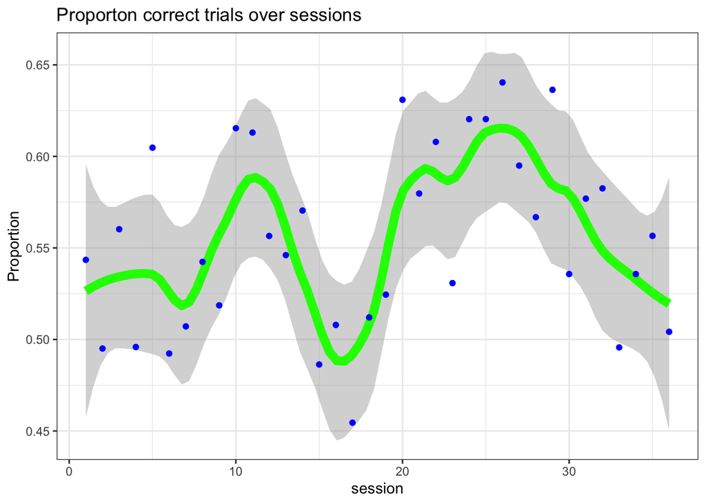

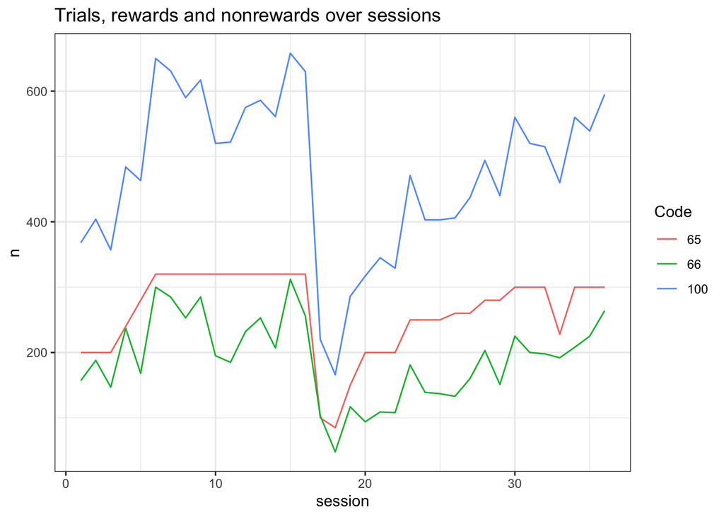

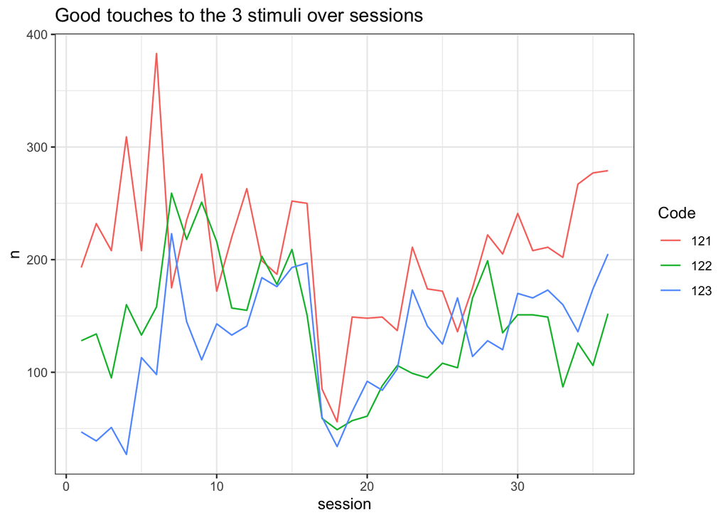

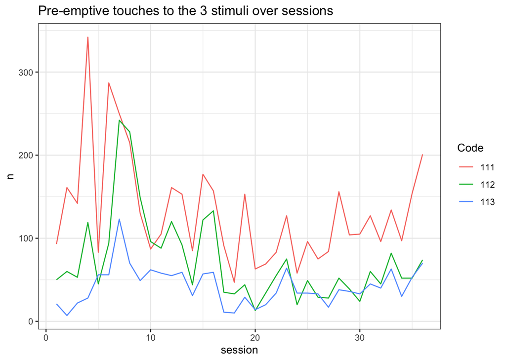

This script now builds a trial by trial matrix to help the trial analysis, and populates it with the necessary information on each trial and block

This allows us to summarise what the monkey(s) are doing within and across blocks.

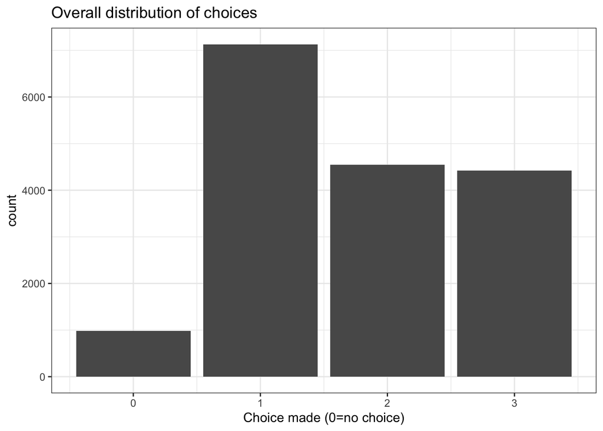

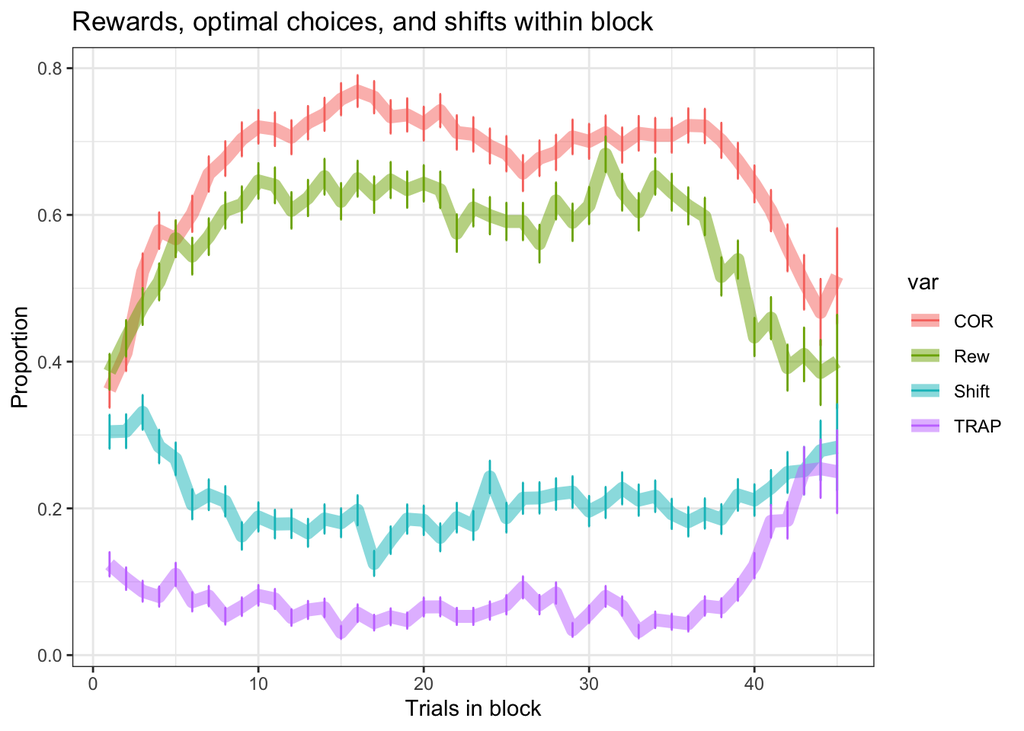

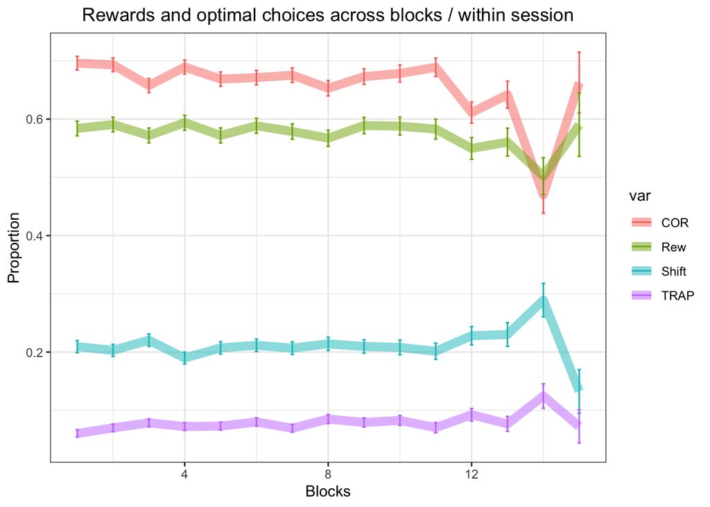

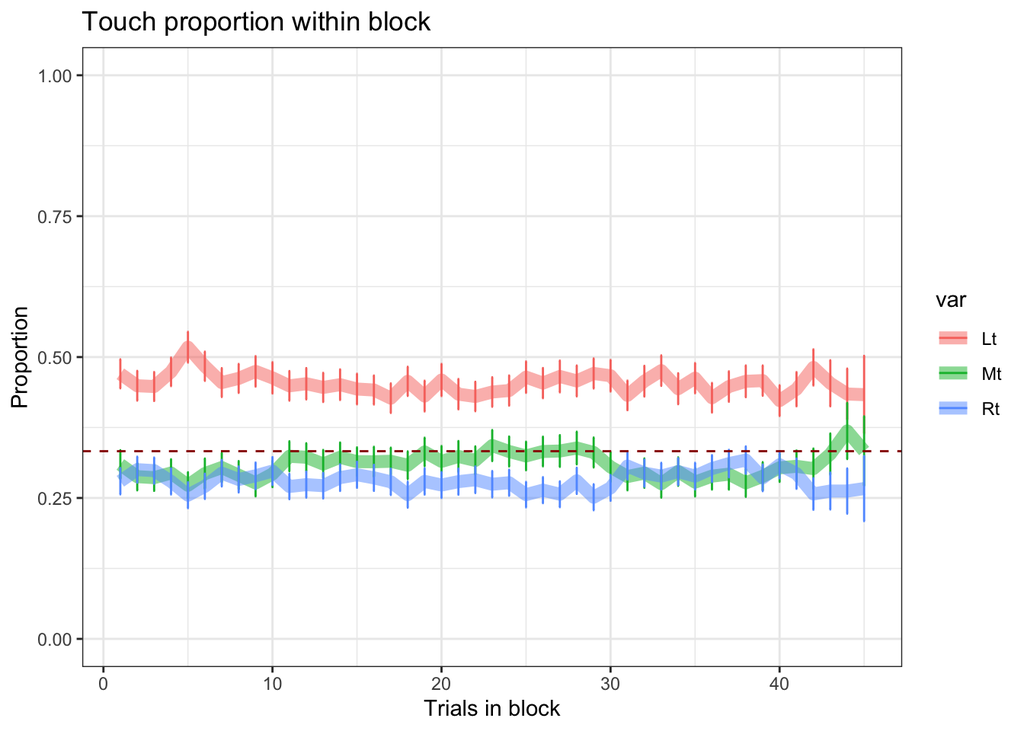

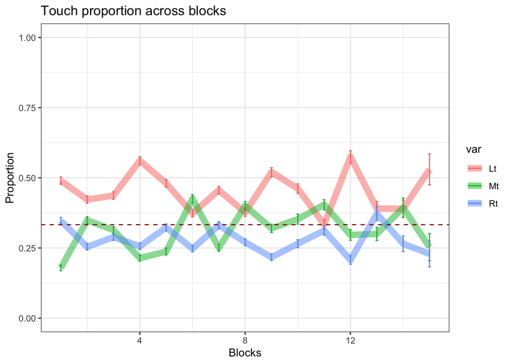

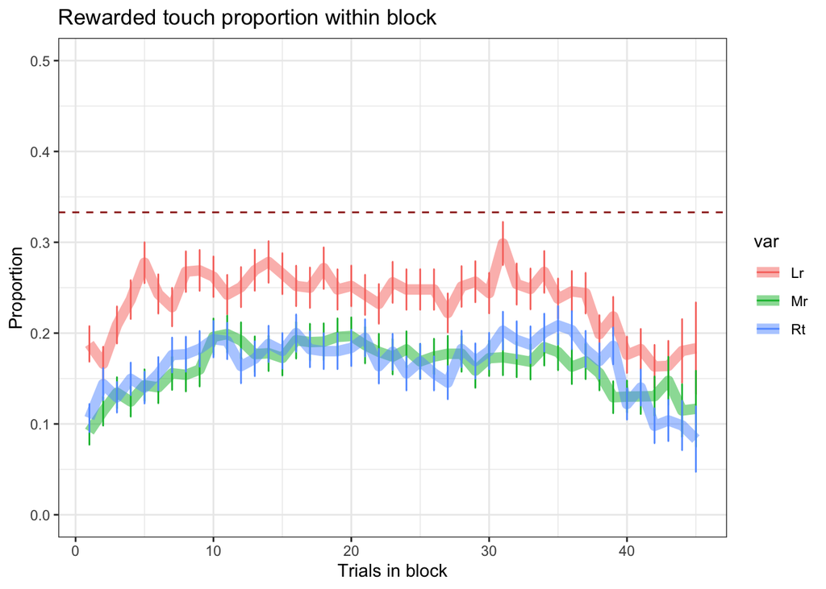

Under what circumstances do monkeys shift choice?

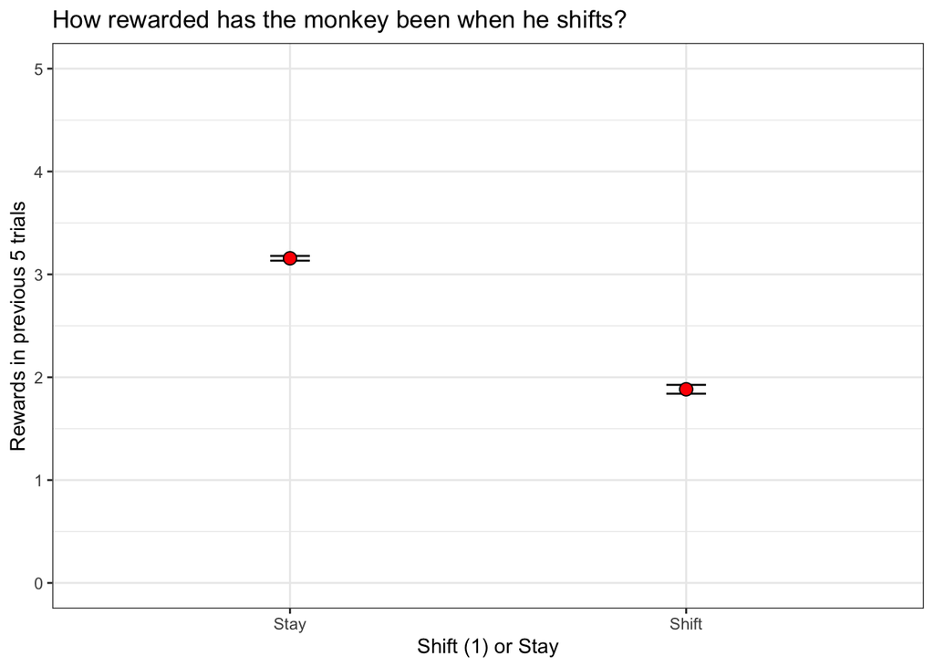

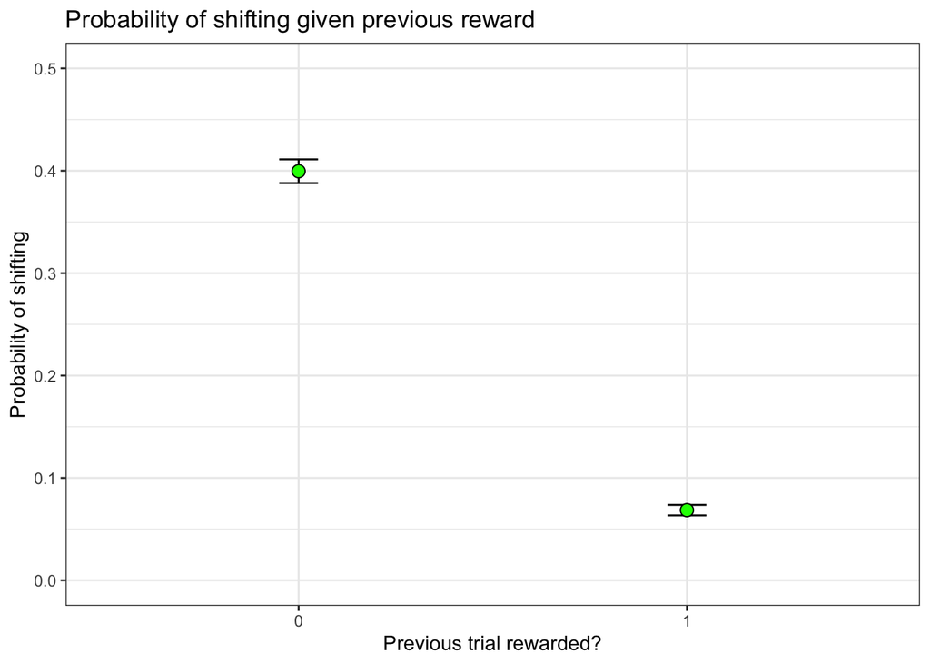

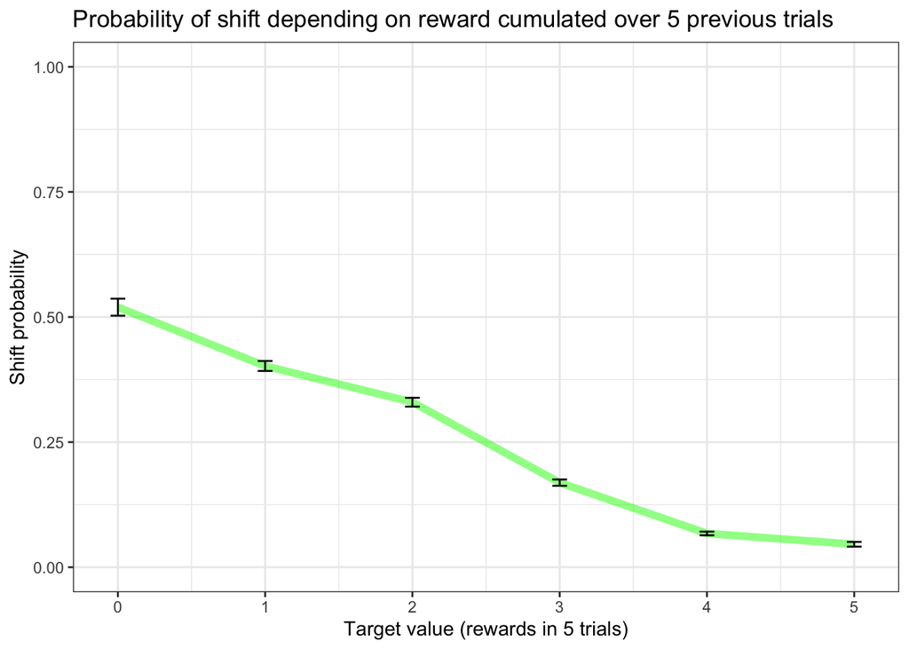

In sum (300322)

- Yuri is rewarded now in about 60% of trials
- Consistent bais towards the left stimulus in good and bad touches
- Expected within-block learning
- Not much TOT in performance
- Shifts when has been receiving fewer rewards
- Only really shifts after an incorrect

To do - Cluster the blocks in terms of strategy that the animal is using. Maybe use variance of the within block pattern? Poss contributing variables: —Pattern of exploration —Solidity of exploitation —RTs over time? —Re-exploration?